# Week 5 / Day 2

# MVP

## Q1

Load in the libraries you need, and look at the backpack data. Take note of variable names and dimensions.

```r
# Load Libraries
library(tidyverse)
library(scales)
```

```r
# Read In Data
backpacks <- CodeClanData::backpack
```

```r
glimpse(backpacks)
```

```
Rows: 100
Columns: 9
$ backpack_weight <int> 9, 8, 10, 6, 8, 5, 8, 4, 5, 2, 8, 21, 11, 11, 12, 11, 13, …
$ body_weight     <int> 125, 195, 120, 155, 180, 240, 170, 185, 130, 120, 135, 160…
$ ratio           <dbl> 0.0720000, 0.0410256, 0.0833333, 0.0387097, 0.0444444, 0.0…
$ back_problems   <int> 1, 0, 1, 0, 0, 0, 0, 1, 0, 0, 0, 0, 0, 1, 1, 0, 1, 0, 1, 0…
$ major           <fct> Bio, Philosophy, GRC, CSC, EE, History, CM, ARCE, Bio, Bio…
$ year            <int> 3, 5, 4, 6, 2, 0, 3, 5, 4, 5, 3, 5, 4, 4, 3, 4, 4, 3, 3, 3…
$ sex             <fct> Female, Male, Female, Male, Female, Male, Male, Female, Fe…
$ status          <fct> U, U, U, G, U, G, U, U, U, U, U, U, U, U, U, U, U, U, U, U…
$ units           <int> 13, 12, 14, 0, 14, 0, 15, 18, 14, 8, 15, 12, 16, 16, 12, 1…
```

## Q2

What is the distribution of backpack weights that students are carrying? Choose an appropriate graph to show the distribution.

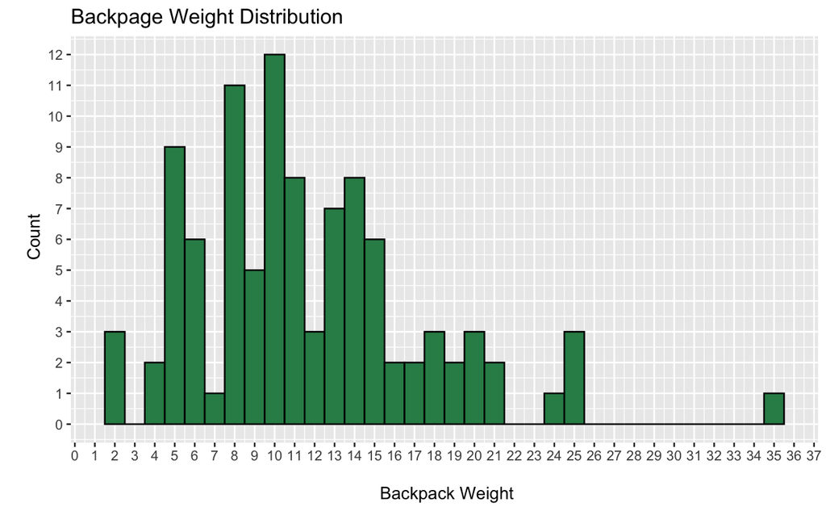

```r
backpacks %>%
  ggplot() +
  geom_histogram(aes(x = backpack_weight),
                 binwidth = 1,
                 fill = "seagreen",
                 colour = "black") +
  scale_x_continuous(breaks=0:40) +
  scale_y_continuous(breaks=0:15) +
  labs(
    x = "\n Backpack Weight",
    y = "\n Count",
    title = "Backpage Weight Distribution")
```

Summary: - More backpacks are ‘10’ in weight than any other weight. - There is one outlier a ‘35’ in weight which might skew average weight calculations. - When increasing the bin width to 5, we can see that the 10-15 weight category has the most bags.

## Q3

Are there differences in backpack weight between sex?

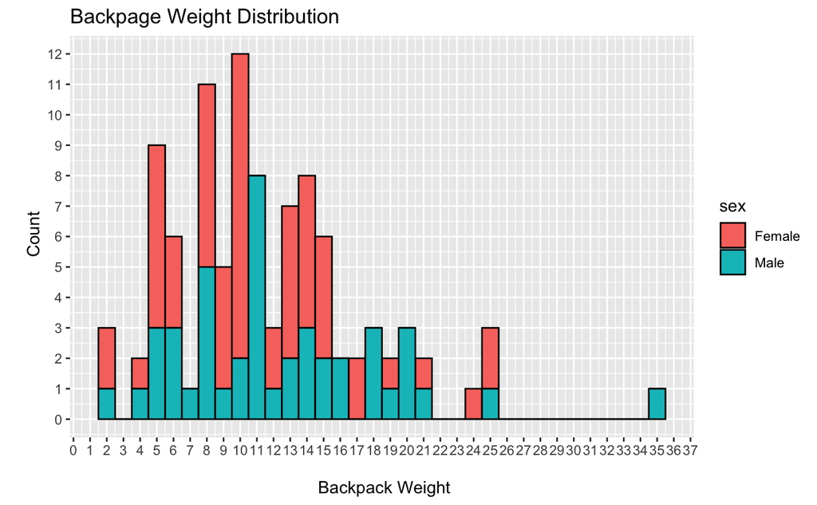

```r
backpacks %>%
  ggplot() +
  geom_histogram(aes(x = backpack_weight, fill = sex),
                 binwidth = 1,
                 colour = "black") +
  scale_x_continuous(breaks=0:40) +
  scale_y_continuous(breaks=0:15) +
  labs(
    x = "\n Backpack Weight",
    y = "\n Count",
    title = "Backpage Weight Distribution")
```

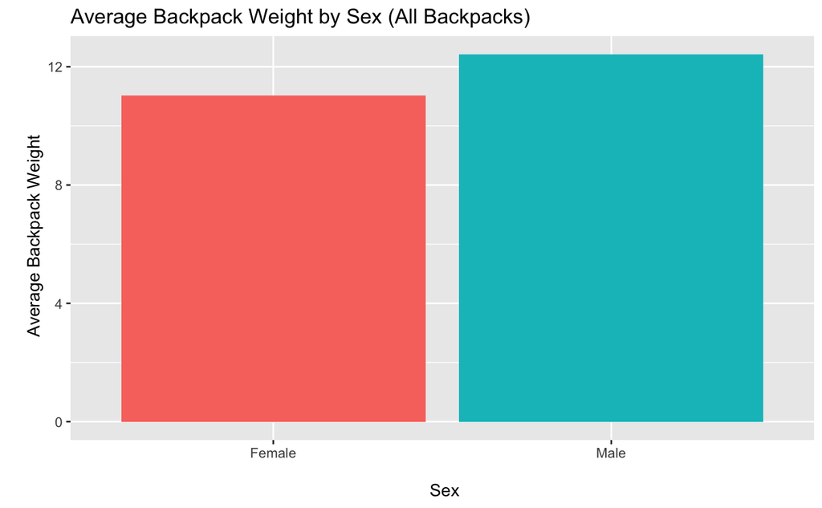

```r
backpacks %>%
  group_by(sex) %>%
  summarise(avg_backpack_weight = mean(backpack_weight)) %>%
  ggplot() +
  geom_col(aes(x = sex, y = avg_backpack_weight, fill = sex), show.legend = FALSE) +
  labs(
    x = "\n Sex",
    y = "\n Average Backpack Weight",
    title = "Average Backpack Weight by Sex (All Backpacks)")
```

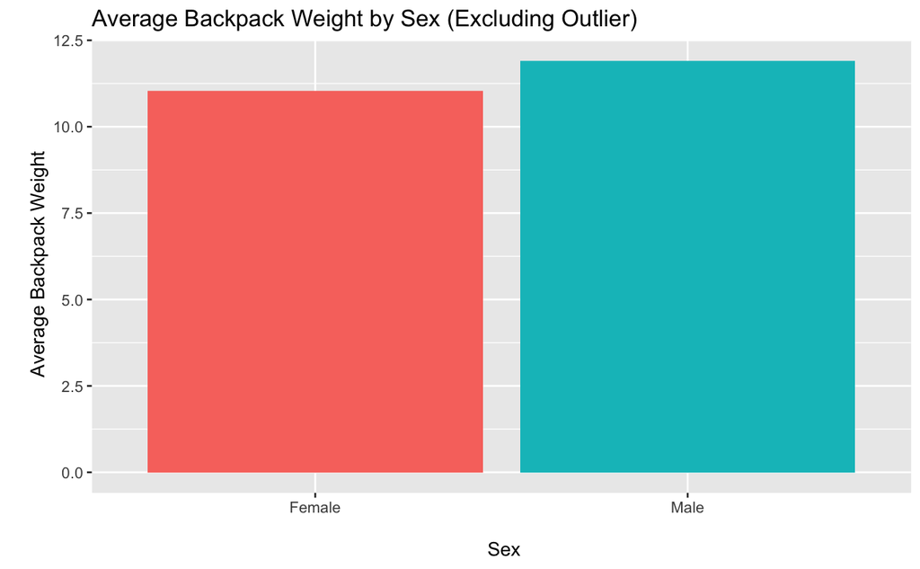

```r
backpacks %>%
  filter(backpack_weight != 35) %>%
  group_by(sex) %>%
  summarise(avg_backpack_weight = mean(backpack_weight)) %>%
  ggplot() +
  geom_col(aes(x = sex, y = avg_backpack_weight, fill = sex), show.legend = FALSE) +
  labs(
    x = "\n Sex",
    y = "\n Average Backpack Weight",
    title = "Average Backpack Weight by Sex (Excluding Outlier)")
```

Summary: - From the histogram it is difficult to identify any significant differences in backpack weight between the sex. - This is supported when looking at the mean backpack weight between each sex, as although the average weight of male backpacks is higher than the average weight of female backpacks it is not by much. It should also be noted that the male mean of all backpacks will have been impacted by the outlier and we can see this in the plot that excludes this value from the mean calculation where the mean values are slightly closer together.

## Q4

What is the relationship between body weight and backpack weight?

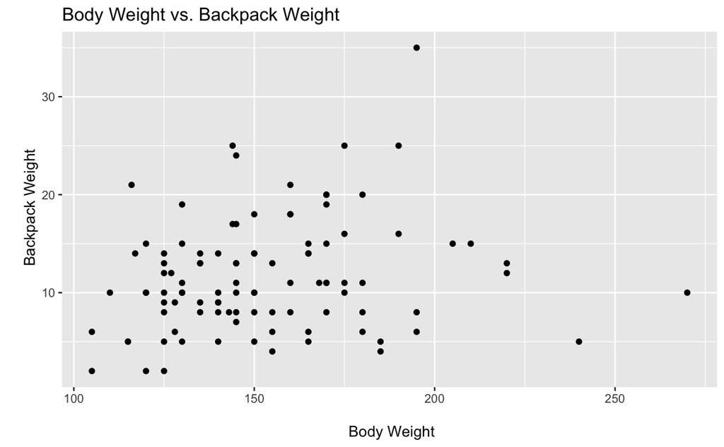

```r
backpacks %>%
  ggplot() +
  geom_point(aes(x = body_weight, y = backpack_weight)) +
  labs(
    x = "\n Body Weight",
    y = "\n Backpack Weight",
    title = "Body Weight vs. Backpack Weight")
```

Summary: There is no strong relationship between body weight and backpack weight, although there is a slight lean towards lower body weights being related to low backpack weights.

## Q5

Is this relationship different between men and women? Choose an appropriate plot and interpret your findings.

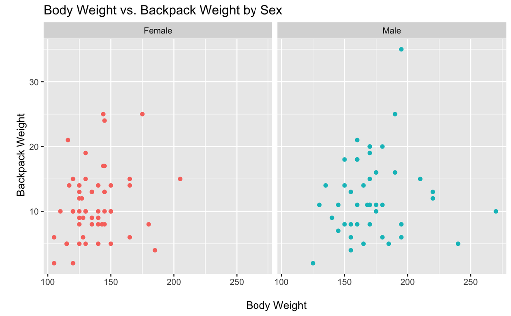

```r
backpacks %>%
  ggplot() +
  geom_point(aes(x = body_weight, y = backpack_weight, colour = sex),
             show.legend = FALSE) +
  facet_wrap(~sex) +
  labs(
    x = "\n Body Weight",
    y = "\n Backpack Weight",
    title = "Body Weight vs. Backpack Weight by Sex")
```

Summary: Females: There remains no strong relationship between body weight and backpack weight. Males: Backpack weight initially increases with body weight, before decreasing again.

## Q6

What proportion of students report back pain?

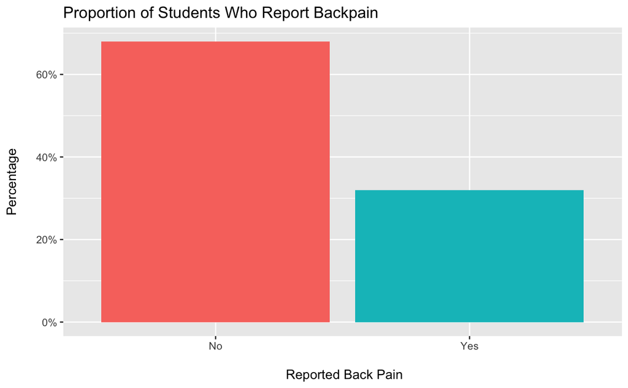

```r
backpacks %>%
  ggplot() +
  geom_bar(aes(x = factor(back_problems),
               y = after_stat(count / sum(count)),
               fill = factor(back_problems)),
           show.legend = FALSE) +
  scale_y_continuous(labels = scales::percent) +
  scale_x_discrete(labels = c("0" = "No", "1" = "Yes")) +
  labs(
    x = "\n Reported Back Pain",
    y = "Percentage\n",
    title = "Proportion of Students Who Report Backpain")
```

Summary: Slightly over 30% of students have reported backpain.

## Q7

Is this proportion different between men and women?

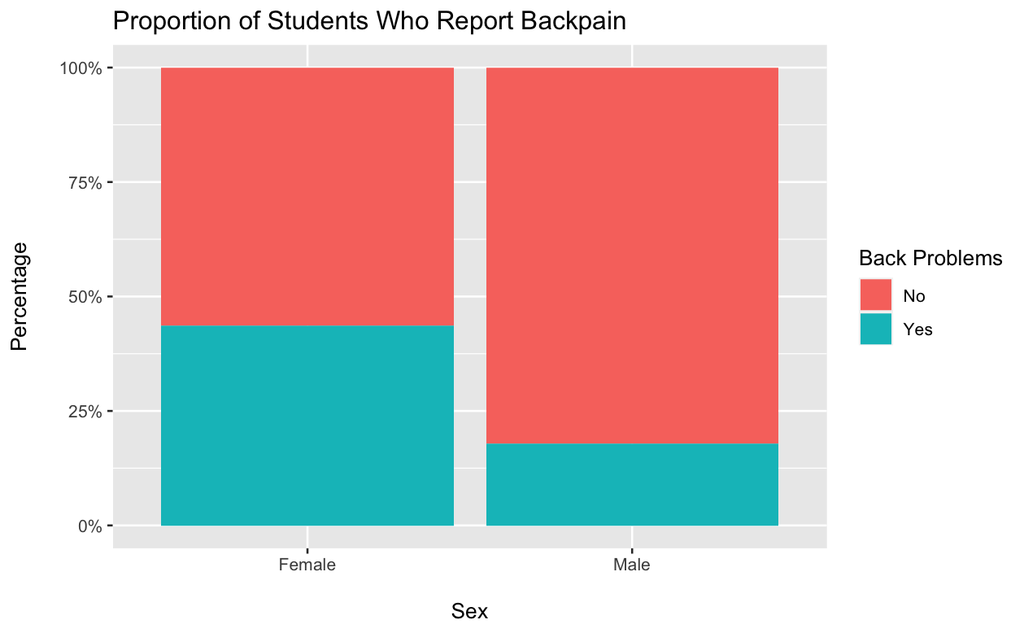

```r
backpacks %>%
  ggplot() +
  geom_bar(aes(x = sex, fill = factor(back_problems)),
           position = "fill") +
  scale_y_continuous(labels = scales::percent) +
  scale_fill_discrete(name = "Back Problems", labels = c("No", "Yes")) +
  labs(
    x = "\nSex",
    y = "Percentage\n",
    title = "Proportion of Students Who Report Backpain")
```

Summary: A lower percentage of males, than females, have reported back problems.

## Q8

Now you’ve investigated your data separately, create plots to describe the relationship between backpack weight, body weight, gender and reported backpain.

Try both backpack_weight and body_weight as well as the ratio.

Hint: faceting would be useful here.

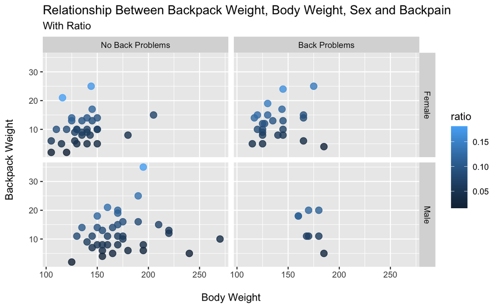

```r
facet_names <- as_labeller(c("0" = "No Back Problems", "1" = "Back Problems",
                             "Male" = "Male", "Female" = "Female"))

backpacks %>%
  mutate(back_problems = factor(back_problems)) %>%
  ggplot() +
  geom_point(aes(x = body_weight,
                 y = backpack_weight,
                 colour = ratio), alpha = 0.8, size = 3) +
  facet_grid(sex ~ back_problems, labeller = facet_names) +
  labs(
    x = "\nBody Weight",
    y = "Backpack Weight\n",
    title = "Relationship Between Backpack Weight, Body Weight, Sex and Backpain",
    subtitle = "With Ratio")
```

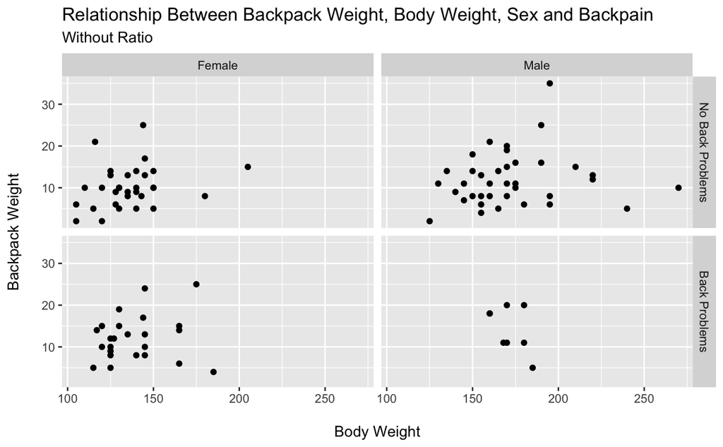

```r
facet_names <- as_labeller(c("0" = "No Back Problems", "1" = "Back Problems",
                             "Male" = "Male", "Female" = "Female"))

backpacks %>%
  mutate(back_problems = factor(back_problems)) %>%
  ggplot() +
  geom_point(aes(x = body_weight,
                 y = backpack_weight)) +
  facet_grid(back_problems ~ sex, labeller = facet_names) +
  labs(
    x = "\nBody Weight",
    y = "Backpack Weight\n",
    title = "Relationship Between Backpack Weight, Body Weight, Sex and Backpain",
    subtitle = "Without Ratio")
```

```r
NA
NA
```

Summary: From the above plots, it is difficult to identify any strong relationship between backpack weight, body weight, sex, reported backpain and ratio.